# spaMM_introduction

```r
library(MASS)
library(spaMM)
library(dplyr)
```

```r
library(ggplot2)
library(raster)
```

## reference

`spaMM`: - https://kimura.univ-montp2.fr/~rousset/spaMM/spaMMintro.pdf - https://www.r-bloggers.com/2019/09/spatial-regression-in-r-part-1-spamm-vs-glmmtmb/ **簡單介紹spaMM**

## Matérn covariance function

是統計學中的一個協方差函數。它常被用於定義兩點測量值之間的協方差。由於該協方差只取決於**兩點間的距離**，因而是平穩的。如使用**歐幾里得**距離來定義距離，此時的馬特恩協方差函數是各向同性的。(取自維基百科)

因此通常使用該協方差矩陣來解釋空間之間的相關性。

$$C_{\nu}(d) = {\sigma^2}\frac{2^{1-\nu}}{\Gamma(\nu)}(\sqrt{2\nu}\frac{d}{\rho})K_{\nu}(\sqrt{2\nu}\frac{d}{\rho})$$

- $d$: 兩點的距離
- $\Gamma(.)$: $\Gamma(.)$ 函數
- $\rho, \nu$: 非負參數，$\rho$ 為 scale parameter(尺度參數)，$\nu$ 為 smoothing parameter(平滑參數)，越大越平滑
- ${\displaystyle K_{\nu }}$: 第二類貝索函數

當$\nu = 0.5$:

$$C_{\nu = 0.5}(d) = {\sigma^2}exp(-\frac{d}{\rho})$$

當$\nu \rightarrow \infty$:

$$\mathop{lim}\limits_{\nu \rightarrow \infty} C_{\nu}(d) = {\sigma^2}exp(-\frac{d^2}{\rho^2})$$

**不過`spaMM`的 $\rho$ 是這邊的`倒數`，因為這篇文章說 $C_{\nu = 0.5}(d) = {\sigma^2}exp(-{d}{\rho})$，$\mathop{lim}\limits_{\nu \rightarrow \infty} C_{\nu}(d) = {\sigma^2}exp({-d^2}{\rho^2})$**

https://rdrr.io/cran/spaMM/man/Matern.corr.html

## Cauchy covariance function

$$C_{cau}(d) = (1-Nuggest)(1+(\rho d)^{\nu})(longdep/\nu))$$

- $Nuggest$: 金塊效應，算是某種誤差
- $\rho$: `rho`，尺寸參數(scaling factor)
- $\nu$:`shape`，形狀（平滑）參數，若距離為歐式距離，$0< \nu \leq 2$；若為大圓距離 (Great-circle distance)，$0< \nu \leq 1$。
- $longdep$: `longdep`，給出相關性隨距離漸近減小的指數，大於零的實數。

https://rdrr.io/cran/spaMM/man/CauchyCorr.html

## General features of spaMM

### Model formulation

$$g(\boldsymbol\mu) =\boldsymbol \eta = \boldsymbol X \boldsymbol \beta+\boldsymbol b = \boldsymbol X \boldsymbol \beta+ \boldsymbol Z \bf v$$

- $g(.)$ : link function
- $\boldsymbol b$ : 隨機效應，由已知的 “design matrix” $ Z$ 與 $\boldsymbol v$ 組成。
- $\lambda$ 為隨機效應(Random effect)的變異數(Variance)，$\phi$ 為殘差(Residuals)的變異數(Variance)。

**`注意`，以上在說隨機效應彼此沒有關聯的時候，阿有關聯的時候會呈現的是一些關聯矩陣，例如上面介紹的Matérn或者Cauchy（論文是這麼說的啦！）**

`u are independent realizations of some reference distribution (e.g., gaussian).`

`spaMM` 會提供固定效應的參數($\boldsymbol \beta$)的估計與隨機效應的分布情形（the variances of $u_i$ and of the residual error $e_i$）以及 $\boldsymbol Z$ 的相關係數(例如前面說的$\rho , \nu$)

### Response families

目前有： - **gaussian** - **Gamma** - **poisson** - **binomial** - **negative-binomial** （NB 有自己的執行方式，可以看看`negbin`） - **COMPoisson** - **零截斷(zero-truncated variants) 的 Poisson 與 negative-binomial** (see help(Tpoisson) or help(Tnegbin)

### Random effect (`spaMM.pdf` p.136)

其中 $\boldsymbol v$ 可以再更加延伸為 $\bf v = f(\bf u)$，其中 $f(.)$ 為另外的 link function，$\bf u$ 服從一些某個特定分布的獨立變數(例如常態分佈)，也可以(被假設為)服從一些空間自相關模型，如Matern (as described in the above examples)、 Cauchy; grid-based approximations of classical geostatistical models (Lindgren et al., 2011), here denoted “Interpolated Markov Random Fields” 等等。

$$\bf v = f(\bf u)$$

- 若$\boldsymbol u$為獨立同分配(iid)，可以有以下的分配假設：
  - **Guassion**
  - **Beta-distributed**
  - **Gamma-distributed**
  - **Inverse-Gamma-distributed**
- 若隨機效應彼此之間有關係（$\bf u$ not indepoendent），則可以將隨機效應表示成 $\bf Mv$, $\bf M = ZL \ or \ ZAL$
  - $\bf Z$: 通常是一個關聯矩陣,兩者相鄰為1，不相鄰為0。
  - $\bf A$: The optional A factor can also be given by the optional “AMatrices” attribute of covStruct.
  - $\bf L$: 對於空間的隨機效應來說，通常為**Cholesky “square root”**，由Matern等距離相關矩陣分解而成。(For spatial random effects, L is typically the Cholesky “square root” of a correlation matrix determined by the random effect specification (e.g., Matern(…))

**Cholesky “square root”**：當$\bf A$ 為實數正定，則可分解唯一分解成$\bf A = GG^T$，其中$\bf G$ 為下三角矩陣，其主對角元素皆為正數。

#### COMPoisson family

Conway-Maxwell-Poisson 是以計數型的 Poisson 為基礎發展出來的分配，是為了解決那些過度分散或者過度集中(over- and underdispersion)的計數型分配。

$$Pr(y;\lambda, \nu_{CMP}) = \frac{\lambda^y}{(y!)^{\nu_{CMP}}Z(\lambda, \nu_{CMP})}$$
$$Z(\lambda, \nu_{CMP}) = \sum^ \infty_{k=0}\frac{\lambda^k}{(k!)^{\nu_{CMP}}}$$

- $\nu_{CMP}$: 其值越小，分布程度越廣(overdispersion); 其值越大，分布程度越集中(underdispersion);$\nu_{CMP} = 1$ 的時候就是 poisson 分配。

## Further examples

### Simulation

```r
library(MASS)
rSample <- function(nb,rho,sigma2_u,resid,intercept,slope,pairs=TRUE) {
## sample pairs of adjacent locations
if (pairs) {
  x <- rnorm(nb/2); x <- c(x,x+0.001)
  y <- rnorm(nb/2); y <- c(y,y+0.001)
} else {x <- rnorm(nb);y <- rnorm(nb)}

  dist <- dist(cbind(x,y)) ## distance matrix between locations
  m <- exp(-rho*as.matrix(dist)) ## correlation matrix
  b <- mvrnorm(1,rep(0,nb),m*sigma2_u) ## correlated random effects
  pred <- sample(nb) ## some predictor variable
  obs <- intercept+slope*pred + b +rnorm(nb,0,sqrt(resid)) ## response
  data.frame(obs=obs,x,y,pred=pred)
}
set.seed(123)
d1 <- rSample(nb=40,rho=3,sigma2_u=0.5,resid=0.5,intercept=-1,slope=0.1)
```

#### plot

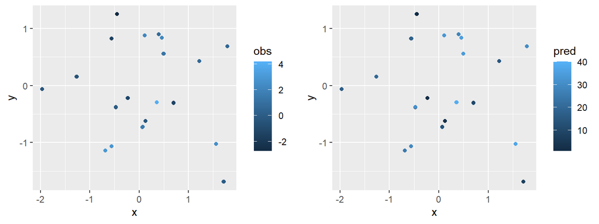

```r
p1 = qplot(data = d1,x = x, y = y, color = obs)
p2 = qplot(data = d1,x = x, y = y, color = pred)
ggpubr::ggarrange(p1, p2, ncol = 2)
```

#### MaternCorr (`corrMatrix` )

`spaMM.pdf` (p.38)

```r
MLdistMat <- MaternCorr(proxy::dist(d1[,c("x","y")]),
nu=0.5,rho=0.05)
```

```r
data(scotlip)
lipfit <- HLCor(cases~I(prop.ag/10)+adjacency(1|gridcode)
+offset(log(expec)),
data=scotlip,family=poisson(),adjMatrix=Nmatrix)

lipfit_com <- fitme(cases~I(prop.ag/10)+adjacency(1|gridcode)
+offset(log(expec)),
data=scotlip,family=COMPoisson(nu = .9),adjMatrix=Nmatrix)
```

```r
summary(lipfit_com)
```

```
## formula: cases ~ I(prop.ag/10) + adjacency(1 | gridcode) + offset(log(expec))
## Estimation of corrPars and lambda by Laplace ML approximation (p_v).
## Estimation of fixed effects by Laplace ML approximation (p_v).
## Estimation of lambda by 'outer' ML, maximizing p_v.
## family: COMPoisson(nu=0.9)( link = loglambda )
##  ------------ Fixed effects (beta) ------------
##                Estimate Cond. SE  t-value
## (Intercept)   -0.009122   0.1972 -0.04625
## I(prop.ag/10)  0.382755   0.1157  3.30875
##  --------------- Random effects ---------------
## Family: gaussian( link = identity )
##                    --- Correlation parameters:
##     1.rho
## 0.1740081
##            --- Variance parameters ('lambda'):
## lambda = var(u) for u ~ Gaussian;
##    gridcode  :  0.1379
## # of obs: 56; # of groups: gridcode, 56
##  ------------- Likelihood values  -------------
##                        logLik
## p_v(h) (marginal L): -163.778
```

## The real data (Stary dogs)

### Function

#### pdf_Plot

```r
pdf_plot <- function(x, idx = c(rep(TRUE, length(x)))){
  g = ggplot()+
    geom_histogram(aes(x = x[idx], y = ..density..),
                   fill = '#557C55', alpha = 0.8)+
    geom_density(aes(x = x[idx], y = ..density..),
                 color = '#062C30', size = 1)+
    theme_bw()
  return(g)
}
```

#### Point_Plot

```r
point_plot <- function(x,county, idx = c(rep(TRUE, length(x)))){
  idx.c = Variable_df$COUNTYNAME == county
  df = Variable_df[idx.c,]
  g = ggplot()+
    geom_point(aes(x = df$X[idx], y = df$Y[idx], color = x[idx] , size = abs(x[idx])))+
     scale_colour_gradient2(low = "#313552",mid = "#FBF8F1", high = "#632626")


  return(g)
}
```

使用 `spaMM` 作為主要使用的套件

### Tidy the data

```r
path = '..\\..\\Roaming-Dogs-Data\\'

# Variable_df <- read.csv(paste0(path, "@Taiwan_sampling_village_variable\\Taiwan_sampling_village_variable.shp" ), fileEncoding = 'utf-8')
Variable_shp<-shapefile(paste0(path, "@Taiwan_sampling_village_variable\\Taiwan_sampling_village_variable.shp" ),encoding = 'utf-8')
Variable_shp@data["School"] <- rowSums(Variable_shp@data[c("Ele","Junior" ,"Senior")])
Variable_shp@data["Student"] <- rowSums(Variable_shp@data[c("Ele_stu","Junior_stu" ,"Senior_stu")])
Variable_shp@data[is.na(Variable_shp@data)] <- 0

Variable_shp@data$Nr = Variable_shp@data$Nr %>% as.integer()
```

```r
counties = "臺北市"
idx.county = Variable_shp@data$COUNTYNAME == counties
sum(idx.county)
```

```
## [1] 37
```

```r
col_X =
  c( "Cluster",# 分群
     "Hospital","Clinic", "Temple", "School", "Train.stat", # 公共建設
     "Student", "Train.crow", # 人流
     "high_rat",   "mid_rat","low_rat", "M_F_RAT" ,"P_H_CNT","H_CNT", "P_DEN", "YOUN_DEP","OLD_DEP","AGING_IDX", # 人口統計(教育程度、人口密度...)
     "Income_mea","Income_sta", # 村里收入
     "Area_sqkm")
col_y = c("Nr")
```

```r
for(i in c(col_X, col_y, "P_CNT", "X","Y")){

  Variable_shp@data[i] = sapply(Variable_shp@data[i], function(x) as.numeric(x))
}
```

```r
Variable_df = Variable_shp@data
```

# Cluster

```r
for (i in c(1:4)){

print(sum(Variable_df$Cluster[idx.county] == i))

}
```

```
## [1] 37
## [1] 0
## [1] 0
## [1] 0
```

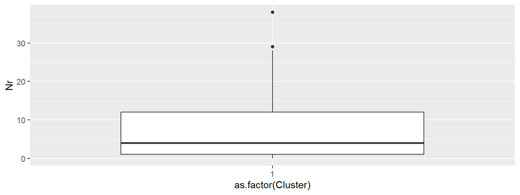

```r
g = ggplot(data = Variable_df[Variable_df$COUNTYNAME == counties, ])+
  geom_boxplot(aes(x = as.factor(Cluster), y = Nr))
g
```

### Correlation

```r
corr = cor(Variable_df[Variable_df$COUNTYNAME == counties, c(col_y, col_X)])
idx = abs(corr[,col_y])>.15
col_X_02 = names(idx)[idx]; col_X_02 = col_X_02[col_X_02 != col_y]

corr[idx,idx]
```

```
##                   Nr <NA>       Clinic     high_rat      mid_rat     low_rat
## Nr         1.0000000   NA -0.238632782 -0.418791979  0.394456755  0.38982987
## <NA>              NA   NA           NA           NA           NA          NA
## Clinic    -0.2386328   NA  1.000000000  0.149085006 -0.006350696 -0.19465167
## high_rat  -0.4187920   NA  0.149085006  1.000000000 -0.838610322 -0.97388830
## mid_rat    0.3944568   NA -0.006350696 -0.838610322  1.000000000  0.69304358
## low_rat    0.3898299   NA -0.194651672 -0.973888302  0.693043577  1.00000000
## M_F_RAT    0.3417714   NA -0.274527688 -0.757312989  0.425293627  0.82497523
## P_H_CNT    0.1554213   NA  0.152750423 -0.003757197  0.136290601 -0.05182953
## H_CNT     -0.3655955   NA  0.244242727  0.392120403 -0.236494603 -0.42036666
## P_DEN     -0.4848630   NA  0.370324375  0.446851204 -0.309450638 -0.46239130
## YOUN_DEP  -0.3739723   NA  0.253179956  0.459190192 -0.332638320 -0.46905674
## AGING_IDX  0.2360378   NA -0.218942563 -0.211226000 -0.005871652  0.28198270
## Area_sqkm  0.3981216   NA -0.196018190 -0.380137115  0.168538341  0.43283014
##              M_F_RAT      P_H_CNT       H_CNT       P_DEN    YOUN_DEP
## Nr         0.3417714  0.155421289 -0.36559549 -0.48486304 -0.37397232
## <NA>              NA           NA          NA          NA          NA
## Clinic    -0.2745277  0.152750423  0.24424273  0.37032437  0.25317996
## high_rat  -0.7573130 -0.003757197  0.39212040  0.44685120  0.45919019
## mid_rat    0.4252936  0.136290601 -0.23649460 -0.30945064 -0.33263832
## low_rat    0.8249752 -0.051829532 -0.42036666 -0.46239130 -0.46905674
## M_F_RAT    1.0000000 -0.187722346 -0.37966978 -0.45057744 -0.44066017
## P_H_CNT   -0.1877223  1.000000000 -0.11095562  0.03810946  0.62675888
## H_CNT     -0.3796698 -0.110955617  1.00000000  0.42433269  0.09762119
## P_DEN     -0.4505774  0.038109462  0.42433269  1.00000000  0.41178948
## YOUN_DEP  -0.4406602  0.626758883  0.09762119  0.41178948  1.00000000
## AGING_IDX  0.4205116 -0.727769315 -0.11078477 -0.24443828 -0.81456342
## Area_sqkm  0.5034037 -0.020009022 -0.41838147 -0.32617647 -0.35151325
##              AGING_IDX   Area_sqkm
## Nr         0.236037828  0.39812158
## <NA>                NA          NA
## Clinic    -0.218942563 -0.19601819
## high_rat  -0.211226000 -0.38013711
## mid_rat   -0.005871652  0.16853834
## low_rat    0.281982699  0.43283014
## M_F_RAT    0.420511584  0.50340365
## P_H_CNT   -0.727769315 -0.02000902
## H_CNT     -0.110784774 -0.41838147
## P_DEN     -0.244438279 -0.32617647
## YOUN_DEP  -0.814563417 -0.35151325
## AGING_IDX  1.000000000  0.43325000
## Area_sqkm  0.433250001  1.00000000
```

### Fitting the model

#### split the data (train and test)

```r
set.seed(111)
n.train = as.integer(sum(idx.county)*0.8)
VILL.train = Variable_df$VILLCODE[idx.county] %>% sample(n.train)
VILL.test = Variable_df$VILLCODE[idx.county][!(Variable_df$VILLCODE[idx.county] %in% VILL.train)]
```

#### Make the dataframe

```r
resi.fit.df = data.frame(VILLCODE = Variable_df$VILLCODE[idx.county],
                         COUNTYNAME = Variable_df$COUNTYNAME[idx.county],
                         TOWNNAME = Variable_df$TOWNNAME[idx.county],
                         VILLNAME = Variable_df$VILLNAME[idx.county],
                         X = Variable_df$X[idx.county],
                         Y = Variable_df$Y[idx.county],
                         Nr= Variable_df$Nr[idx.county],
                         Cluster = Variable_df$Cluster[idx.county],
                         P_H_CNT = Variable_df$P_H_CNT[idx.county],
                         Income_mea = Variable_df$Income_mea[idx.county],
                         Area_sqkm = Variable_df$Area_sqkm[idx.county])
```

#### Fitting the data

```r
# Nr~Cluster+School+Temple+P_H_CNT+Income_mea+Area_sqkm+Matern(1|X+Y)

glmm_ComPo_C = fitme(Nr~Temple+P_H_CNT+Area_sqkm+Cauchy(1|X+Y),data= Variable_df[Variable_df$VILLCODE %in% VILL.train, c(col_y, col_X,  "X", "Y")],
      family = COMPoisson())
glmm_ComPo_M = fitme(Nr~Temple+P_H_CNT+Area_sqkm+Matern(1|X+Y),data= Variable_df[Variable_df$VILLCODE %in% VILL.train, c(col_y, col_X,  "X", "Y")],
      family = COMPoisson())
```

```r
cat("================= Cauchy Matrix =================\n\n")
```

```
## ================= Cauchy Matrix =================
```

```r
glmm_ComPo_C %>% summary()
```

```
## formula: Nr ~ Temple + P_H_CNT + Area_sqkm + Cauchy(1 | X + Y)
## Estimation of corrPars, lambda and COMP_nu by Laplace ML approximation (p_v).
## Estimation of fixed effects by Laplace ML approximation (p_v).
## Estimation of lambda and COMP_nu by 'outer' ML, maximizing p_v.
## family: COMPoisson(nu=1.193)( link = loglambda )
##  ------------ Fixed effects (beta) ------------
##             Estimate Cond. SE t-value
## (Intercept)  -1.5726   4.2478 -0.3702
## Temple        0.3164   0.3859  0.8200
## P_H_CNT       1.0669   1.6560  0.6443
## Area_sqkm     0.1866   0.1014  1.8394
##  --------------- Random effects ---------------
## Family: gaussian( link = identity )
##                    --- Correlation parameters:
##      1.shape    1.longdep        1.rho
##  0.520117687 12.373106118  0.002429456
##            --- Variance parameters ('lambda'):
## lambda = var(u) for u ~ Gaussian;
##    X + Y  :  2.606
## # of obs: 29; # of groups: X + Y, 29
##  ------------- Likelihood values  -------------
##                         logLik
## p_v(h) (marginal L): -88.07838
```

```r
cat("\n\n================= Matern Matrix =================\n\n")
```

```
##
##
## ================= Matern Matrix =================
```

```r
glmm_ComPo_M %>% summary()
```

```
## formula: Nr ~ Temple + P_H_CNT + Area_sqkm + Matern(1 | X + Y)
## Estimation of corrPars, lambda and COMP_nu by Laplace ML approximation (p_v).
## Estimation of fixed effects by Laplace ML approximation (p_v).
## Estimation of lambda and COMP_nu by 'outer' ML, maximizing p_v.
## family: COMPoisson(nu=1.193)( link = loglambda )
##  ------------ Fixed effects (beta) ------------
##             Estimate Cond. SE t-value
## (Intercept)  -1.5731   4.2476 -0.3704
## Temple        0.3164   0.3858  0.8201
## P_H_CNT       1.0671   1.6559  0.6444
## Area_sqkm     0.1865   0.1014  1.8394
##  --------------- Random effects ---------------
## Family: gaussian( link = identity )
##                    --- Correlation parameters:
##       1.nu      1.rho
## 4.81475756 0.03153694
##            --- Variance parameters ('lambda'):
## lambda = var(u) for u ~ Gaussian;
##    X + Y  :  2.606
## # of obs: 29; # of groups: X + Y, 29
##  ------------- Likelihood values  -------------
##                         logLik
## p_v(h) (marginal L): -88.07836
```

```r
Variable_df[Variable_df$VILLCODE %in% VILL.train, c(col_y, col_X,  "X", "Y"),]
```

```
##     Nr Cluster Hospital Clinic Temple School Train.stat Student Train.crow
## 546  0       1        0      0      0      0          0       0      0.000
## 549  6       1        0      0      0      1          0     659      0.000
## 550 38       1        0      1      0      0          0       0      0.000
## 551  1       1        0      3      0      2          0    1419      0.000
## 553 26       1        0      1      2      0          0       0      0.000
## 554  3       1        0      0      1      1          1     513   7955.464
## 555  8       1        0      0      2      1          0    1418      0.000
## 556  1       1        0      6      0      0          0       0      0.000
## 559 22       1        0      1      0      0          0       0      0.000
## 560  2       1        0      0      0      0          0       0      0.000
## 561  0       1        0      1      0      0          0       0      0.000
## 562 10       1        1      3      1      1          0     503      0.000
## 563  0       1        0      0      1      0          0       0      0.000
## 564  5       1        0      0      2      0          0       0      0.000
```

[output cut: 75 more lines]